# MA 415/615 Project 1

February 19, 2018

## I. Introduction

According to CNN, Apprehensions at the US-Mexico border reached historic lows in April of 2017. This downward trend has been interpreted as a sign that President Trump's anti-immigrant sentiment has deterred many from attempting to cross the border. The total amount of apprehensions at the Southwest border was 11,129, which is the lowest it has been in 17 years. The lowest monthly total before Trump took office was in December of 2011 when there were 18,983 apprehensions. it is particularly noteworthy that drops in apprenehsions occured in February and March because these two months had not seen decreases since 2000. April, on the other hand, has experienced more fluctuations, sometimes decreasing and sometimes increasing apprehensions.

## II. Analysis

Data provided by the U.S. Border Patrol for the years 2010 and 2017 was used to analyze how Border Apprehensions have changed over time. These graphs illustrate that although border apprehensions vary greatly by sector, the overall trend is a decline in border apprehensions along the U.S. southwest border.

## Bar graph for 2010

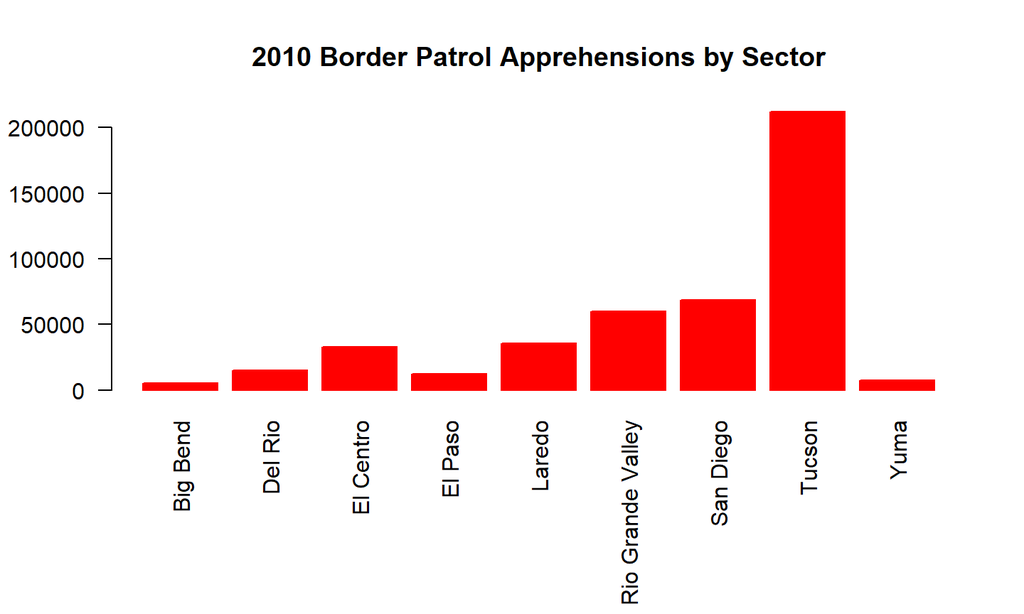

## Bar graph for 2017

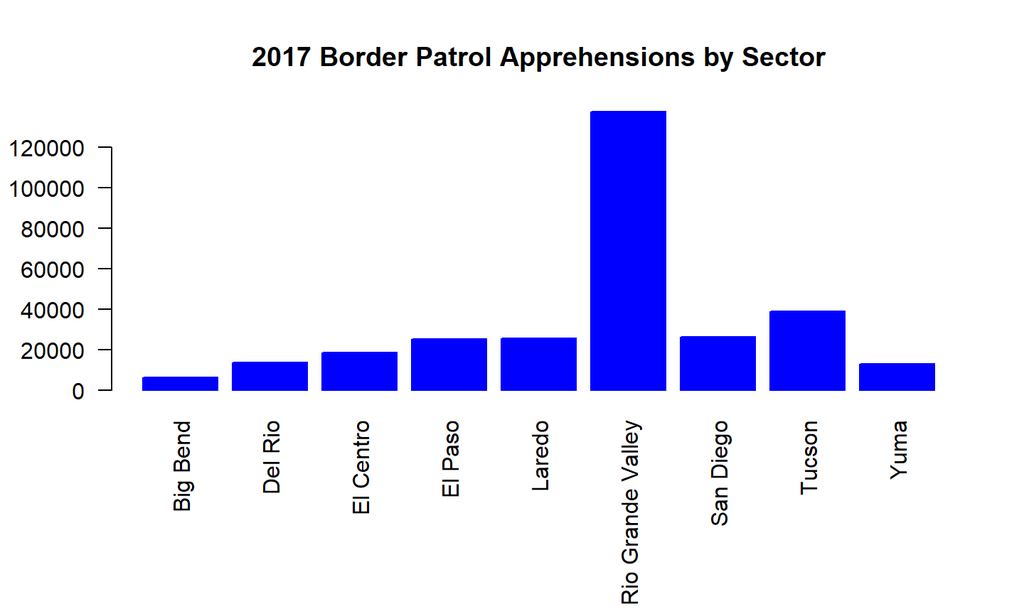

## Comparing Sectors and Months using Double Bar Graphs

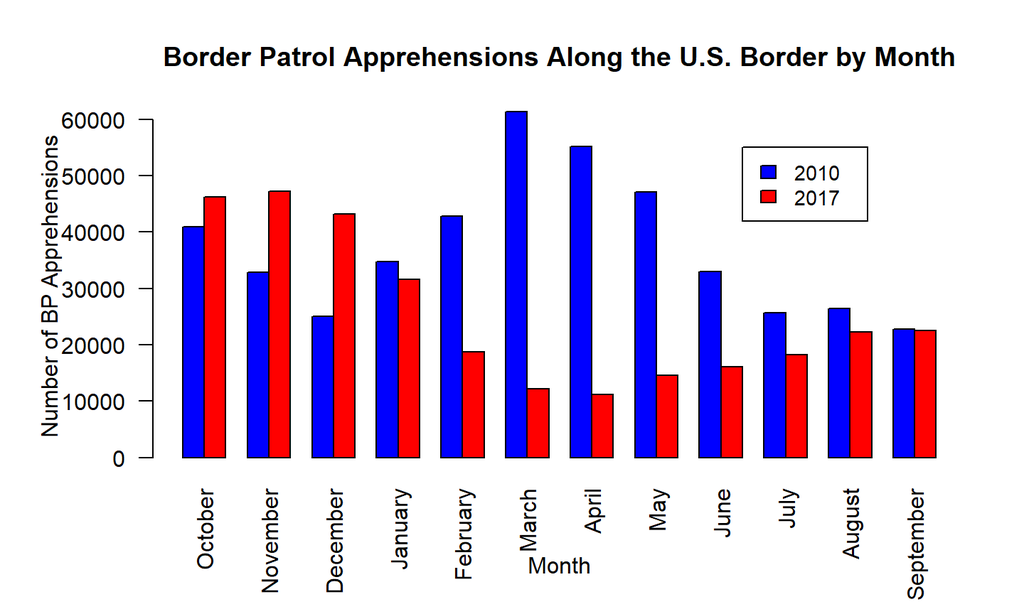

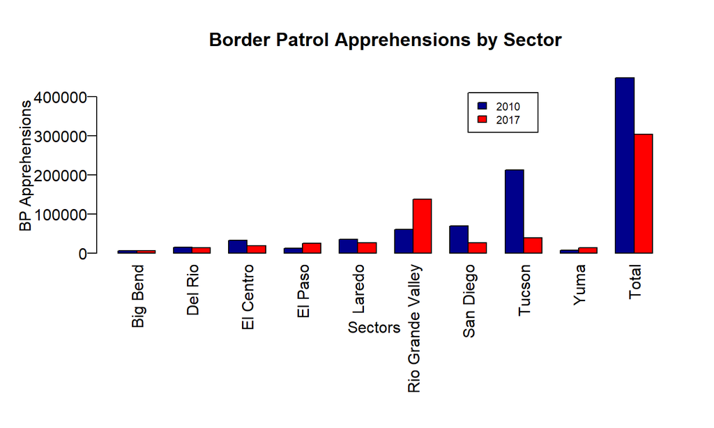